# Reproducible Research: Peer Assessment 1

## Loading and preprocessing the data

```r
library(dplyr,warn.conflicts = FALSE)
library(ggplot2,quietly=TRUE,warn.conflicts = FALSE)
library(xtable,quietly=TRUE,warn.conflicts = FALSE)
library(gridExtra,quietly=TRUE,warn.conflicts = FALSE)
unzip("./activity.zip")
data <- read.csv("./activity.csv")
```

Below is a historgram of the steps taken each day:

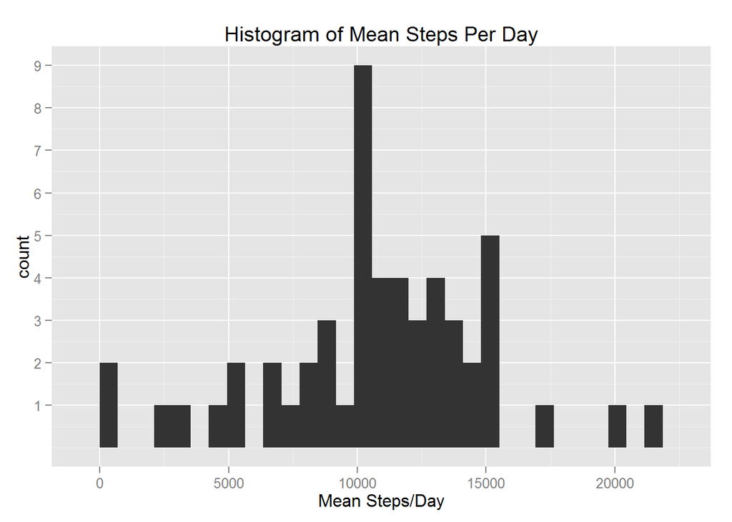

```r
#Remove NA data
data_no_na <- na.omit(data)
#Summarize data
grp_by_StepsPerDay <- group_by(data_no_na,date)
summary <- summarize(grp_by_StepsPerDay,total_steps=sum(steps),mean_steps=mean(steps),median_steps=median(steps))
#Plot data
ggplot(summary, aes(x=total_steps)) + geom_histogram() + scale_y_continuous(breaks=seq(1,10,1)) + xlab("Mean Steps/Day") + ggtitle("Histogram of Mean Steps Per Day")
```

```r
#Print data
xt <- xtable(summary)
print(xt,type = "html")
```

|  | date | total_steps | mean_steps | median_steps |
| --- | --- | --- | --- | --- |
| 1 | 2012-10-02 | 126 | 0.44 | 0.00 |
| 2 | 2012-10-03 | 11352 | 39.42 | 0.00 |
| 3 | 2012-10-04 | 12116 | 42.07 | 0.00 |
| 4 | 2012-10-05 | 13294 | 46.16 | 0.00 |
| 5 | 2012-10-06 | 15420 | 53.54 | 0.00 |
| 6 | 2012-10-07 | 11015 | 38.25 | 0.00 |
| 7 | 2012-10-09 | 12811 | 44.48 | 0.00 |
| 8 | 2012-10-10 | 9900 | 34.38 | 0.00 |
| 9 | 2012-10-11 | 10304 | 35.78 | 0.00 |
| 10 | 2012-10-12 | 17382 | 60.35 | 0.00 |
| 11 | 2012-10-13 | 12426 | 43.15 | 0.00 |
| 12 | 2012-10-14 | 15098 | 52.42 | 0.00 |
| 13 | 2012-10-15 | 10139 | 35.20 | 0.00 |
| 14 | 2012-10-16 | 15084 | 52.38 | 0.00 |
| 15 | 2012-10-17 | 13452 | 46.71 | 0.00 |
| 16 | 2012-10-18 | 10056 | 34.92 | 0.00 |
| 17 | 2012-10-19 | 11829 | 41.07 | 0.00 |
| 18 | 2012-10-20 | 10395 | 36.09 | 0.00 |
| 19 | 2012-10-21 | 8821 | 30.63 | 0.00 |
| 20 | 2012-10-22 | 13460 | 46.74 | 0.00 |
| 21 | 2012-10-23 | 8918 | 30.97 | 0.00 |
| 22 | 2012-10-24 | 8355 | 29.01 | 0.00 |
| 23 | 2012-10-25 | 2492 | 8.65 | 0.00 |
| 24 | 2012-10-26 | 6778 | 23.53 | 0.00 |
| 25 | 2012-10-27 | 10119 | 35.14 | 0.00 |
| 26 | 2012-10-28 | 11458 | 39.78 | 0.00 |
| 27 | 2012-10-29 | 5018 | 17.42 | 0.00 |
| 28 | 2012-10-30 | 9819 | 34.09 | 0.00 |
| 29 | 2012-10-31 | 15414 | 53.52 | 0.00 |
| 30 | 2012-11-02 | 10600 | 36.81 | 0.00 |
| 31 | 2012-11-03 | 10571 | 36.70 | 0.00 |
| 32 | 2012-11-05 | 10439 | 36.25 | 0.00 |
| 33 | 2012-11-06 | 8334 | 28.94 | 0.00 |
| 34 | 2012-11-07 | 12883 | 44.73 | 0.00 |
| 35 | 2012-11-08 | 3219 | 11.18 | 0.00 |
| 36 | 2012-11-11 | 12608 | 43.78 | 0.00 |
| 37 | 2012-11-12 | 10765 | 37.38 | 0.00 |
| 38 | 2012-11-13 | 7336 | 25.47 | 0.00 |
| 39 | 2012-11-15 | 41 | 0.14 | 0.00 |
| 40 | 2012-11-16 | 5441 | 18.89 | 0.00 |
| 41 | 2012-11-17 | 14339 | 49.79 | 0.00 |
| 42 | 2012-11-18 | 15110 | 52.47 | 0.00 |
| 43 | 2012-11-19 | 8841 | 30.70 | 0.00 |
| 44 | 2012-11-20 | 4472 | 15.53 | 0.00 |
| 45 | 2012-11-21 | 12787 | 44.40 | 0.00 |
| 46 | 2012-11-22 | 20427 | 70.93 | 0.00 |
| 47 | 2012-11-23 | 21194 | 73.59 | 0.00 |
| 48 | 2012-11-24 | 14478 | 50.27 | 0.00 |
| 49 | 2012-11-25 | 11834 | 41.09 | 0.00 |
| 50 | 2012-11-26 | 11162 | 38.76 | 0.00 |
| 51 | 2012-11-27 | 13646 | 47.38 | 0.00 |
| 52 | 2012-11-28 | 10183 | 35.36 | 0.00 |
| 53 | 2012-11-29 | 7047 | 24.47 | 0.00 |

## What is the average daily activity pattern (NA data removed)?

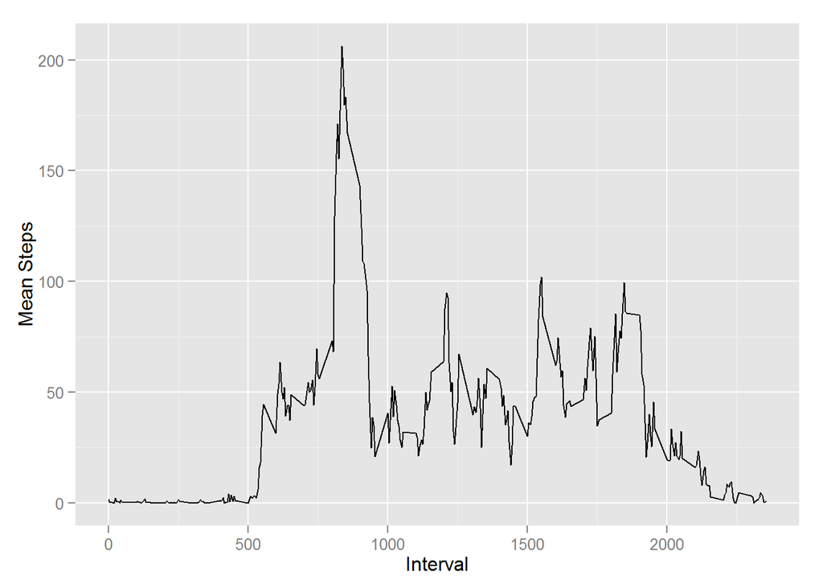

```r
grp_by_MeanStepsPerInterval <- group_by(data_no_na,interval)
summary2 <- summarize(grp_by_MeanStepsPerInterval,interval_mean=mean(steps))

ggplot(summary2, aes(interval, interval_mean)) + geom_line() + xlab("Interval") + ylab("Mean Steps")
```

### Which 5-minute interval, on average across all the days in the dataset, contains the maximum number of steps?

```r
filter(summary2,interval_mean==max(summary2$interval_mean))$interval
```

```
## [1] 835
```

## Imputing missing values

Total number of missing values in the dataset:

```r
sum(is.na(data$steps))
```

```
## [1] 2304
```

Below is a historgram of the steps taken each day with NAs replaced by interval means:

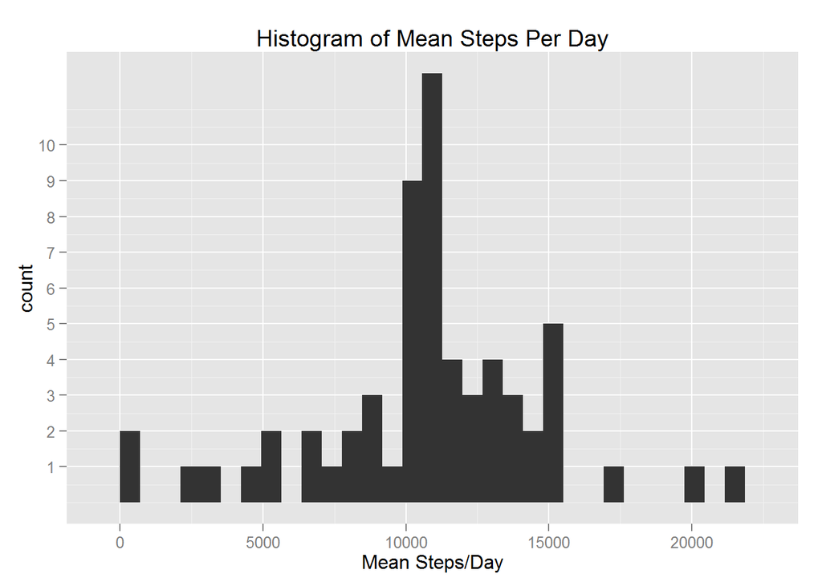

```r
#Default rows with NA for steps to interval mean
mergedData <- merge(data,summary2)
mergedData$steps <- ifelse(is.na(mergedData$steps),mergedData$interval_mean,mergedData$steps)

#Create histogram of total steps per day
grp_by_StepsPerDay2 <- group_by(mergedData,date)
summary3 <- summarize(grp_by_StepsPerDay2,total_steps=sum(steps),mean_steps=mean(steps),median_steps=median(steps))
ggplot(summary3, aes(x=total_steps)) + geom_histogram() + scale_y_continuous(breaks=seq(1,10,1)) + xlab("Mean Steps/Day") + ggtitle("Histogram of Mean Steps Per Day")
```

```r
#Print data
xt2 <- xtable(summary3)
print(xt2,type = "html")
```

|  | date | total_steps | mean_steps | median_steps |
| --- | --- | --- | --- | --- |
| 1 | 2012-10-01 | 10766.19 | 37.38 | 34.11 |
| 2 | 2012-10-02 | 126.00 | 0.44 | 0.00 |
| 3 | 2012-10-03 | 11352.00 | 39.42 | 0.00 |
| 4 | 2012-10-04 | 12116.00 | 42.07 | 0.00 |
| 5 | 2012-10-05 | 13294.00 | 46.16 | 0.00 |
| 6 | 2012-10-06 | 15420.00 | 53.54 | 0.00 |
| 7 | 2012-10-07 | 11015.00 | 38.25 | 0.00 |
| 8 | 2012-10-08 | 10766.19 | 37.38 | 34.11 |
| 9 | 2012-10-09 | 12811.00 | 44.48 | 0.00 |
| 10 | 2012-10-10 | 9900.00 | 34.38 | 0.00 |
| 11 | 2012-10-11 | 10304.00 | 35.78 | 0.00 |
| 12 | 2012-10-12 | 17382.00 | 60.35 | 0.00 |
| 13 | 2012-10-13 | 12426.00 | 43.15 | 0.00 |
| 14 | 2012-10-14 | 15098.00 | 52.42 | 0.00 |
| 15 | 2012-10-15 | 10139.00 | 35.20 | 0.00 |
| 16 | 2012-10-16 | 15084.00 | 52.38 | 0.00 |
| 17 | 2012-10-17 | 13452.00 | 46.71 | 0.00 |
| 18 | 2012-10-18 | 10056.00 | 34.92 | 0.00 |
| 19 | 2012-10-19 | 11829.00 | 41.07 | 0.00 |
| 20 | 2012-10-20 | 10395.00 | 36.09 | 0.00 |
| 21 | 2012-10-21 | 8821.00 | 30.63 | 0.00 |
| 22 | 2012-10-22 | 13460.00 | 46.74 | 0.00 |
| 23 | 2012-10-23 | 8918.00 | 30.97 | 0.00 |
| 24 | 2012-10-24 | 8355.00 | 29.01 | 0.00 |
| 25 | 2012-10-25 | 2492.00 | 8.65 | 0.00 |
| 26 | 2012-10-26 | 6778.00 | 23.53 | 0.00 |
| 27 | 2012-10-27 | 10119.00 | 35.14 | 0.00 |
| 28 | 2012-10-28 | 11458.00 | 39.78 | 0.00 |
| 29 | 2012-10-29 | 5018.00 | 17.42 | 0.00 |
| 30 | 2012-10-30 | 9819.00 | 34.09 | 0.00 |
| 31 | 2012-10-31 | 15414.00 | 53.52 | 0.00 |
| 32 | 2012-11-01 | 10766.19 | 37.38 | 34.11 |
| 33 | 2012-11-02 | 10600.00 | 36.81 | 0.00 |
| 34 | 2012-11-03 | 10571.00 | 36.70 | 0.00 |
| 35 | 2012-11-04 | 10766.19 | 37.38 | 34.11 |
| 36 | 2012-11-05 | 10439.00 | 36.25 | 0.00 |
| 37 | 2012-11-06 | 8334.00 | 28.94 | 0.00 |
| 38 | 2012-11-07 | 12883.00 | 44.73 | 0.00 |
| 39 | 2012-11-08 | 3219.00 | 11.18 | 0.00 |
| 40 | 2012-11-09 | 10766.19 | 37.38 | 34.11 |
| 41 | 2012-11-10 | 10766.19 | 37.38 | 34.11 |
| 42 | 2012-11-11 | 12608.00 | 43.78 | 0.00 |
| 43 | 2012-11-12 | 10765.00 | 37.38 | 0.00 |
| 44 | 2012-11-13 | 7336.00 | 25.47 | 0.00 |
| 45 | 2012-11-14 | 10766.19 | 37.38 | 34.11 |
| 46 | 2012-11-15 | 41.00 | 0.14 | 0.00 |
| 47 | 2012-11-16 | 5441.00 | 18.89 | 0.00 |
| 48 | 2012-11-17 | 14339.00 | 49.79 | 0.00 |
| 49 | 2012-11-18 | 15110.00 | 52.47 | 0.00 |
| 50 | 2012-11-19 | 8841.00 | 30.70 | 0.00 |
| 51 | 2012-11-20 | 4472.00 | 15.53 | 0.00 |
| 52 | 2012-11-21 | 12787.00 | 44.40 | 0.00 |
| 53 | 2012-11-22 | 20427.00 | 70.93 | 0.00 |
| 54 | 2012-11-23 | 21194.00 | 73.59 | 0.00 |
| 55 | 2012-11-24 | 14478.00 | 50.27 | 0.00 |
| 56 | 2012-11-25 | 11834.00 | 41.09 | 0.00 |
| 57 | 2012-11-26 | 11162.00 | 38.76 | 0.00 |
| 58 | 2012-11-27 | 13646.00 | 47.38 | 0.00 |
| 59 | 2012-11-28 | 10183.00 | 35.36 | 0.00 |
| 60 | 2012-11-29 | 7047.00 | 24.47 | 0.00 |
| 61 | 2012-11-30 | 10766.19 | 37.38 | 34.11 |

### There does not seem to be a major impact of replaced NA data with interval means

## Are there differences in activity patterns between weekdays and weekends?

Below are two graphs that capture average steps per interval for weekends and weekdays.

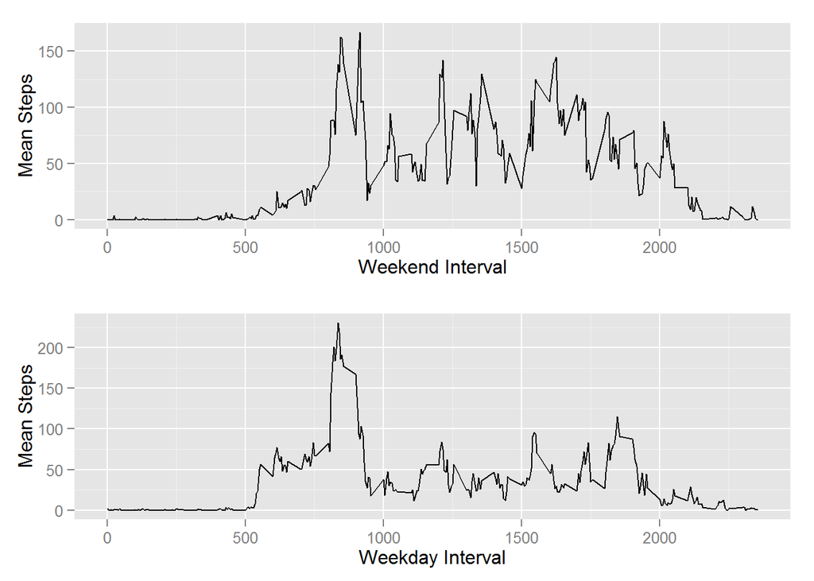

```r
mergedData$dayofweek <- weekdays(as.Date(mergedData$date))
weekends <- mergedData[mergedData$dayofweek %in% c("Saturday","Sunday"),]
weekdays <- mergedData[!mergedData$dayofweek %in% c("Saturday","Sunday"),]

grp_by_MeanStepsPerIntervalWE <- group_by(weekends,interval)
grp_by_MeanStepsPerIntervalWD <- group_by(weekdays,interval)

summaryWE <- summarize(grp_by_MeanStepsPerIntervalWE,interval_mean=mean(steps))
summaryWD <- summarize(grp_by_MeanStepsPerIntervalWD,interval_mean=mean(steps))
pWE <- ggplot(summaryWE, aes(interval, interval_mean)) + geom_line() + xlab("Weekend Interval") + ylab("Mean Steps")
pWD <- ggplot(summaryWD, aes(interval, interval_mean)) + geom_line() + xlab("Weekday Interval") + ylab("Mean Steps")

grid.arrange(pWE, pWD)
```

### There does seem to be difference between weekend and weekday activity. The average of Weekend intervals ramp up and remain at a more constant level of activity relative to weekdays which seems to spike and then level out at a lower average steps per interval.